# Goal 5

Carter Rogers, Nicholas Hunter, Shivam K C

10/25/2019

# Our Problem and Hypothesis:

Some countries are happier than others. We want to find what factors best predict happiness. Therefore, we hypothesize the following: (i) We expect factors such as life expectancy and GDP to be positively correlated with happiness. (ii) We expect factors such as corruption to be negatively correlated with happiness. (iii) We expect Europe to be the happiest continent.

```r
#Loading Libraries
library(ggplot2)
library(dplyr)
library(reshape2)
```

```r
# Import main dataset
WHR = read.csv("World_Happiness_Report_2008-2018.csv")

# Filter most recent year
WHR2018 = WHR %>% filter(Year == 2018)

#Changing column names
names(WHR2018)[names(WHR2018) == "ï..Country.name"] <- "Country.name"

# Load continents
# NA == North America so need to specify na.strings
countries_and_continents = read.csv("countries and continents.csv", na.strings="N/A")


# Merge main dataset with continent data
whr2018_w_continents =  merge(x=WHR2018, y=countries_and_continents, by.x='Country.name', by.y='name')
```

#Distribution of Happiness Score

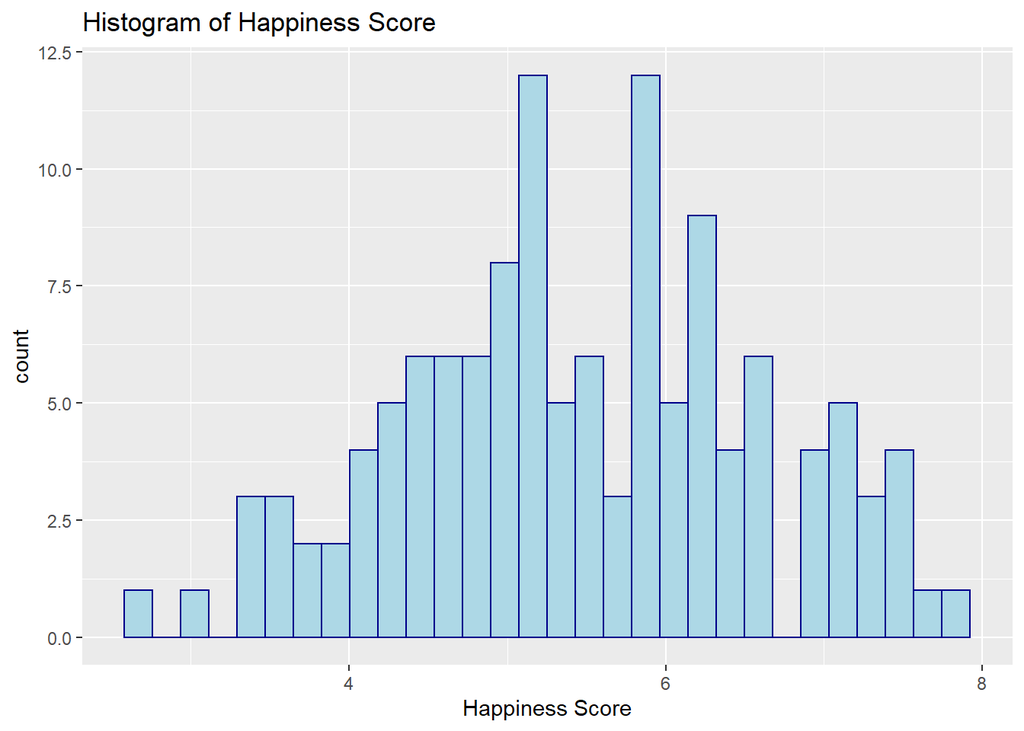

```r
ggplot(data=whr2018_w_continents, aes(x=Life.Ladder))+geom_histogram(
                                            color="darkblue", fill="lightblue")+ggtitle("Histogram of Happiness Score")+xlab("Happiness Score") #histogram code
```

We plotted this graph to observe the distribution of happiness score. Here, the distribution of happiness score is symmetric. This means that there are many countries with average happiness scores.

#Statistics of Happiness Score

```r
summary(whr2018_w_continents$Life.Ladder) #summary of happiness score
```

```
##    Min. 1st Qu.  Median    Mean 3rd Qu.    Max.
##   2.694   4.661   5.409   5.469   6.263   7.858
```

We are using this table to check the statistics (spread and mean) of Happiness Score which is our dependent variable. We observe that the mean Happiness Score of the World in 2018 was 5.469. The maximum score was 7.86 and the minimum score was 2.69.

# Testing Hypothesis 1

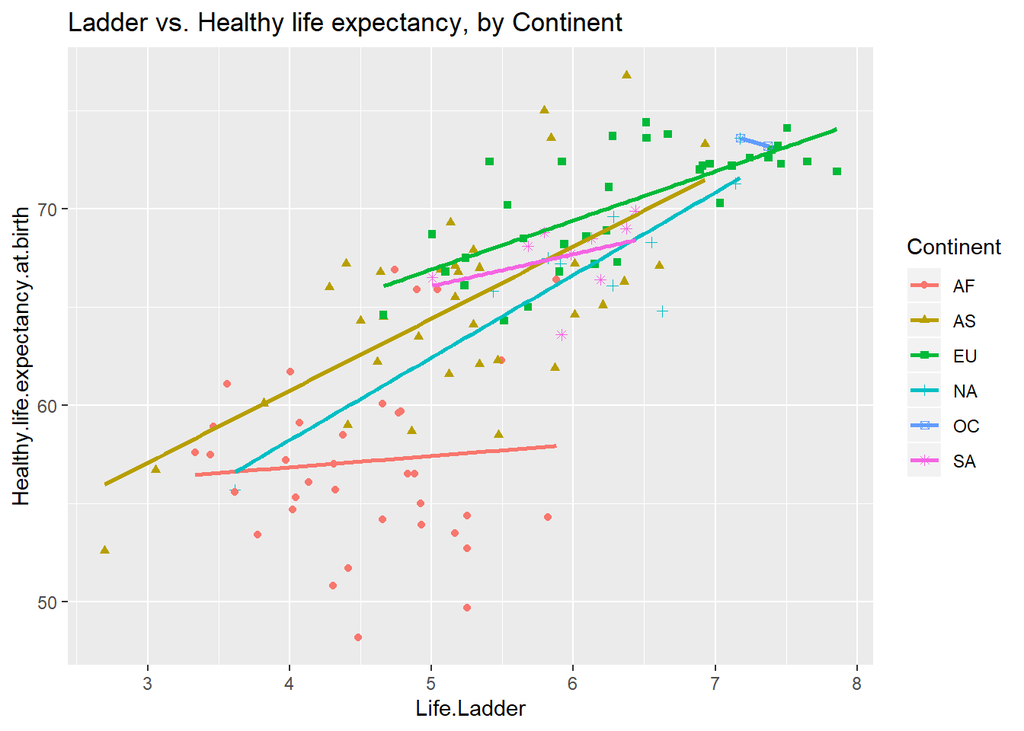

```r
ggplot(whr2018_w_continents, aes(x=Life.Ladder, y=Healthy.life.expectancy.at.birth, shape=Continent, color=Continent))+geom_point()+ggtitle("Ladder vs. Healthy life expectancy, by Continent")+geom_smooth(method=lm, se=FALSE) #Relationship between happiness score and life expectancy among different continents.
```

We constructed this plot in order to examine the relationship between healthy life expectancy for each country and that respective country’s happiness score. We see that European and Asian countries are strongly and positively correlated with happiness. African countries are not as strongly correlated, as the line of best fit has a lower slope than the others.

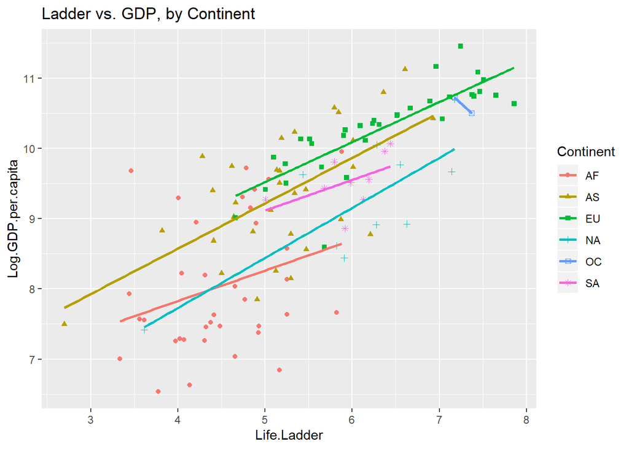

```r
ggplot(whr2018_w_continents, aes(x=Life.Ladder, y=Log.GDP.per.capita, shape=Continent, color=Continent))+geom_point()+ggtitle("Ladder vs. GDP, by Continent")+geom_smooth(method=lm, se=FALSE) #Relationship between happiness score and GDP among different continents.
```

# Testing Hypothesis 3

```r
happiness_by_continent <- whr2018_w_continents %>% group_by(Continent) %>% summarise(count = n(), ladder_avg = mean(Life.Ladder)) #piping to get average happiness scores for each continent.
happiness_by_continent
```

| Continent | count | ladder_avg |
| --- | --- | --- |
| AF | 37 | 4.516237 |
| AS | 34 | 5.172957 |
| EU | 35 | 6.361388 |
| NA | 10 | 6.082594 |
| OC | 2 | 7.273640 |
| SA | 9 | 5.944915 |

We made this table to test our hypothesis 3. We observe Oceanic to have the highest Happiness score, but there are only two countries present in the continent, which is not ideal for comparison among other continents. We do observe (excluding OC) Europe to be the happiest continent.

# Testing Hypothesis 2

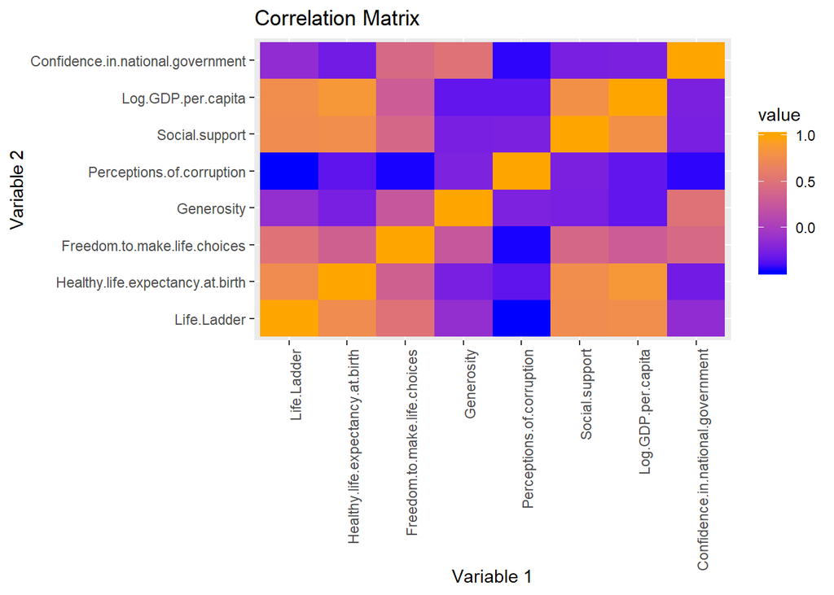

```r
# Select columns of interest
whr_2018_select = whr2018_w_continents %>% select(Life.Ladder, Healthy.life.expectancy.at.birth, Freedom.to.make.life.choices, Generosity, Perceptions.of.corruption, Generosity, Social.support, Log.GDP.per.capita, Confidence.in.national.government)

# Create correlation matrix
cormat <- round(cor(whr_2018_select, use = "complete.obs"),2)

# Melt the matrix
melted_cormat = melt(cormat)

# Plot the correlation data
ggplot(data = melted_cormat, aes(x=Var1, y=Var2, fill=value)) + xlab("Variable 1") + ylab("Variable 2") + ggtitle("Correlation Matrix") + geom_tile()+theme(axis.text.x=element_text(angle=90, hjust=1)) + scale_fill_gradient(low = "blue", high = "orange")
```

This plot shows the correlations between a selected set of variables which we believe could relate to our hypothesis. Here we see stronger correlations between Life.Ladder, which is our self reported happiness score, and GDP per capita, Social Support, Freedom, and Life expectancy. We see weaker correlations with Confidence in Government and Generosity. We also see a negative correlation between happiness and Perceptions of Corruption.

#Comparing Top 3 Happiest Countries from Each Continent

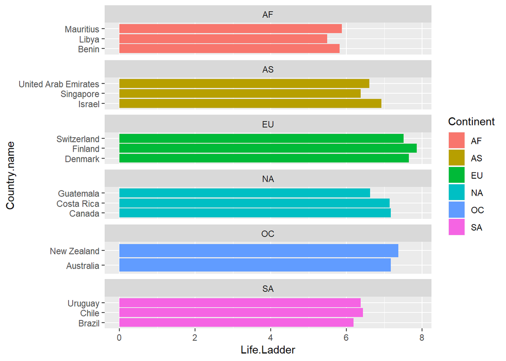

```r
Top_3 <- whr2018_w_continents %>% select(Continent, Country.name,Life.Ladder) %>% group_by(Continent)%>% arrange(desc(Life.Ladder), .by_group = TRUE)%>% slice(1:3) #getting the table

#Now plotting bar plots and comparing

ggplot(Top_3,aes(x=Country.name, y=Life.Ladder, fill = Continent))+geom_bar(stat='identity')+coord_flip()+facet_wrap(~Continent,ncol=1,scales = 'free_y')
```